# The Academy of Sciences, Chennai (Saturday lecture series)

### Center for Theoretical Studies, IIT Kharagpur

## Contents <sup>[1]</sup>

- Hubbard Model
- Ising Model
- SIAM Model

1. ^ We won't to be going into details of the model, rather we will focus on certain special cases which bring out the physics of it.

# Hubbard Model(HM)

- Formulated by Martin Gutzwiller, Junjiro Kanamori and John Hubbard (1963)
- Extension of Tight Binding Model
- The idea was to tackle the corelated behavior of solids.
  - Itenerant Ferromagntism of transition metals such as Fe and Ni
- It features an additional term U(originally known as "I" until PAM Anderson. This is the energy required, if a pair of electrons occupy the same lattice. (Coulomb Repulsion)
- Some well known features
  - It produces both metallic and insulating state depending on value of U
- At half-filling, Mott-Hubbard transition is observed(more about this later).This kind of transition could not be understood in terms of conventional band theory.
- t-J model: High Tc superconductivity
- Experimental realisations of HM has been realised in cold-atom trapping experiments (Nature 415,39-44(2002)

### Anti-Commutation Relation

$$\{\hat{c_{j\sigma}}, \hat{c^\dagger_{j\sigma^\prime}}\} = \delta_{j,l}\delta_{\sigma,\sigma^\prime}$$$$\{\hat{c_{j\sigma}}, \hat{c_{j\sigma}}\} = \{\hat{c^\dagger_{j\sigma}}, \hat{c^\dagger_{j\sigma^\prime}}\} =0 $$

### Constructing the model

- **Kinetics**: We start with a lattice of atoms(sites) on which fermions can move.
- **Interaction**: We add a two particle interaction term modelled by U. The interaction is zero, for zero and one site occupancy but has value U if the site is doubly occupied.

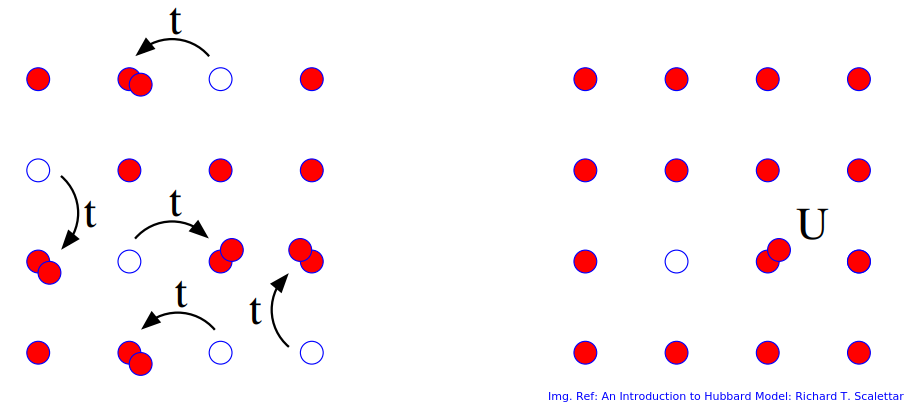

```python
show_("HH_pic.png")
```

## Hubbard Hamiltonian

$$\hat{H} = -t \sum_{\langle j,l \rangle\sigma} (c_{j\sigma}^\dagger c_{l\sigma}) + (c_{l\sigma}^\dagger c_{j\sigma}) + U \sum_{j} n_{j\uparrow}n_{j\downarrow} + \mu \sum_{j}(n_{j\uparrow} + n_{j\downarrow})$$

- The First term is the Kinetic energy. It describes the destruction of an fermion of spin $\sigma$ on site 1 and its creation on site j (or vice-versa). The symbol $\langle j,l \rangle$ emphasizes that hopping is for neaest neighbours.
- The second term is the interaction energy which adds an energy U, if the lattice is doubly occupied
- The final term is the chemical potential which controls the filling. If there is one fermion per site, then it is called "half-filling"

## Hubbard Hamiltonian (PHS)

$c_{l\sigma}^\dagger \rightarrow (-1)^l c_{l\sigma}$

$$\hat{H} = -t \sum_{\langle j,l \rangle\sigma} (c_{j\sigma}^\dagger c_{l\sigma}) + (c_{l\sigma}^\dagger c_{j\sigma}) + U \sum_{j} (n_{j\uparrow}- \frac{1}{2})(n_{j\downarrow}-\frac{1}{2}) + \mu \sum_{j}(n_{j\uparrow} + n_{j\downarrow})$$

### Inorder to understand few things about the Hamiltonian, we will look at the Single-site limit(i.e t=0)

$$\hat{H}_{t=0} = U \sum_{j} (n_{j\uparrow}- \frac{1}{2})(n_{j\downarrow}-\frac{1}{2}) + \mu \sum_{j}(n_{j\uparrow} + n_{j\downarrow})$$

### Possible Configurations and corresponding energy

$$ \begin{align} |0 \rangle : & \frac{U}{4}&\\ |\uparrow(\downarrow) \rangle : & -\frac{U}{4} - \mu&\\ % |\rangle : & -\frac{U}{4} - \mu&\\ |\uparrow \downarrow\rangle : & \frac{U}{4} - 2\mu \end{align} $$

- Using the mentioned eigenvalues , we can construct the partition function $$Z = Tr[e^{-\beta U/4}]$$, and

The occupation is given, by

$$\rho = \langle n_\uparrow + n_\downarrow \rangle = Z^{-1} Tr[(n_\uparrow + n_\downarrow)e^{-\beta \hat{H}}]$$

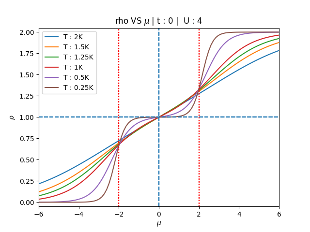

```python
# %%capture
%run rhoMu.ipynb
list_,mu,T,U = create_rho_mu_list(U=4)
images = makes_images_list(list_,U);
# Try a different U
```

```python
display_sequence(images=images)
```

```
<function __main__.display_sequence.<locals>._show(frame=(0, 5))>
```

# Ising Model

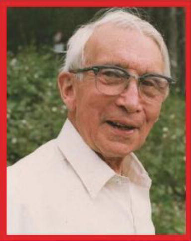

```python
show_("Ernst_Ising.png")
```

- Ising model was invented by Wilhem Lenz(yes!! our very own Lenz's law) and was later used by his student Ernst Ising to study ferromagntism for his doctoral dissertation in 1925.
- He exactly calculated partition function for one-dimensional lattice system of spins. Ising had first proven that no phase transition to a ferromagnetic ordered state occurs in one dimension at any temperature.<sup>[1]</sup>

1. ^ We will see why later.

- Ising asserted that there was no phase transition in any dimension, but was later proved to be wrong.
- Ising Model considers only two spin states, i.e S = $\pm 1$
- In order to explain ferromagnetism, Heisenberg developed his own theory, using complicated interactions of spins, known as Heisenberg model(spins)
- Some Applications of Ising Model:
  - Investigation of spontaneous magnetization in ferromagnetic films, i.e. magnetization in the absence of external magnetic field
  - Spin glasses(solids, possessing no long-range order)

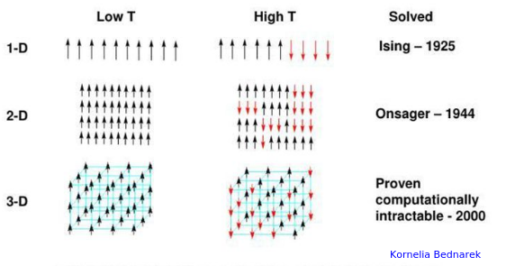

```python
show_("Ising_compare.png")
```

# Enough of handwaving, Show me the model !!

### Consider N atoms in the presence of a z-directed magnetic field of strength H. Suppose that all atoms are identical spin- $\frac{1}{2}$ systems. The total energy of the system is writtem as,

$$ E = -J \sum_{\langle i,j\rangle} s_i s_j - \mu H \sum_{i=1,N} s_i$$

- $\langle i,j\rangle$ is sum over nearest neighbours
- J is the exchnage energy
- $\mu$ is the atomic magnetic moment

## So now what does the model does actually mean?

Since we are only concerned with the nearest neighbour, $-J \sum_{\langle i,j\rangle} s_i s_j$ can be written more explicitly as, $$-J \sum_{i =1}^N s_i s_{i+1}$$

- J > 0, Ferromagnetic interaction (i.e parallel neighboring spins is favoured)
- J < 0, Antiferromagnetic interaction (i.e Anti-parallel neighboring spins is favoured)

# Ising Model in 1D

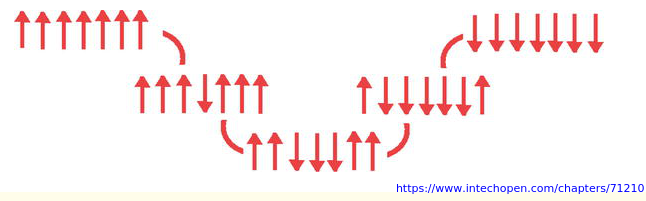

```python
show_("spin_flip_1D.png")
```

- Explanation: if one of the spins get flipped at a random position because of thermal agitation, there is no force available, which can stop the neighboring spins to flip in the same direction. And this process will go on and on, and completely ordered state will not remain stable at a finite temperature

# Ising Model in 2D

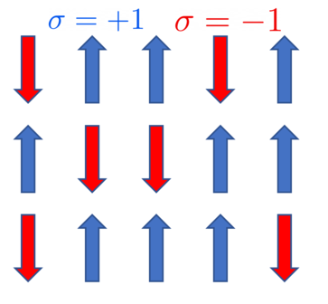

```python
show_("Ising_2D.png")
```

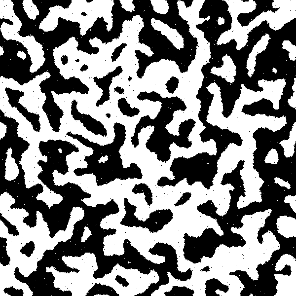

```python
%matplotlib inline
%run Ising.ipynb
N = 600 # N^2 is the number of lattice points
# show_ising_sequence(N)

# Live image not working hence
show_("ising_simulation.png")
```

# Behavior of average spin in Ising Model

## Let's go into little bit more detail and see how does average spin behave

## Let's set up the problem first

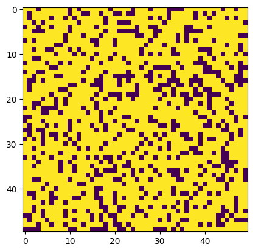

```python
%run Ising2D.ipynb

##create a 2D lattice of size 50 x 50 with negative spin with probability p
lattice_n, N = create_lattice(50,0.25)

#view the lattice
view_lattice(lattice_n)
```

## Now that we have our 2D lattice, let us calculate the spins and energies(calculated using Metropolis Aglgorithm)

```python
%run Ising2D.ipynb
beta = 0.2 # high beta ----> low temp.
spins, energies = metropolis(lattice_n, 1000000, beta, get_energy(lattice_n))
```

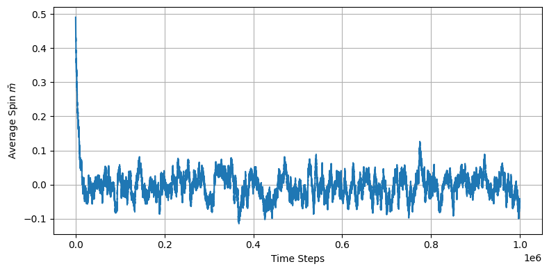

```python
plot_average_spin()
```

# Single Impurity Anderson Model ( SIAM )

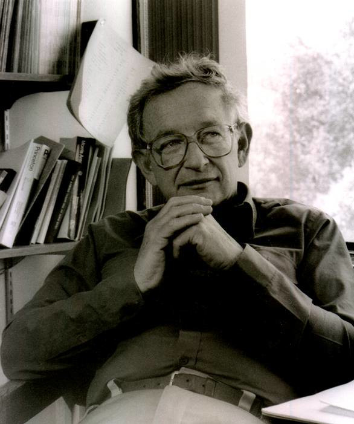

```python
show_("Anderson_photo.jpg")
```

## Anderson Impurity Model

$$ \hat{H} = \hat{H}_{band} + \hat{H}_{imp} + \hat{H}_{hybd} $$$$\hat{H}_{band} = \sum_{k,\sigma} \epsilon_k c_{k\sigma}^\dagger c_{k\sigma} $$$$\hat{H}_{imp} = \sum_{\sigma = \uparrow,\downarrow} \epsilon_0 \hat{n}_{d\sigma} + U \hat{n}_{d\uparrow}\hat{n}_{d\downarrow} $$$$\hat{H}_{hybd} = \sum_{k,\sigma} t_k c_{d\sigma}^\dagger c_{k\sigma} + h.c $$

where,

$$\hat{n}_{d\sigma} \equiv c_{d\sigma}^\dagger c_{d\sigma}$$

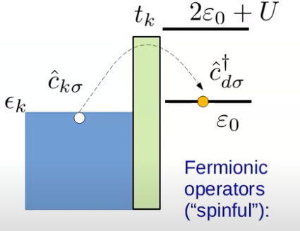

```python
show_("SIAM_Model.png")
```

## Anderson Impurity States

$$\hat{H}_{imp} = \sum_{\sigma = \uparrow,\downarrow} \epsilon_0 \hat{n}_{d\sigma} + U \hat{n}_{d\uparrow}\hat{n}_{d\downarrow} $$

$$\hat{n}_{d\uparrow} = \hat{n}_{d\uparrow} = 0 $$$$E_0 = 0 : \langle 0 | \sum_{\sigma} \hat{n}_{d\sigma} |0 \rangle = 0$$

$$ \text{Either} \ \hat{n}_{d\uparrow} =0 \ \hat{n}_{d\downarrow} = 1 \ \text{or} \ \hat{n}_{d\uparrow} =1 \ \hat{n}_{d\downarrow} = 0$$

$$E_1 = \epsilon_0 : \langle 1 | \sum_{\sigma} \hat{n}_{d\sigma} |1 \rangle = 1$$

$$ \hat{n}_{d\uparrow} =1 \ \hat{n}_{d\downarrow} = 1 $$$$E_1 = 2\epsilon_0 + U : \langle 2 | \sum_{\sigma} \hat{n}_{d\sigma} |2 \rangle = 2$$

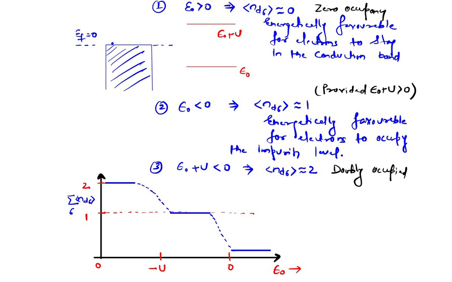

```python
show_("Rough_plot_SIAM.jpg")
```

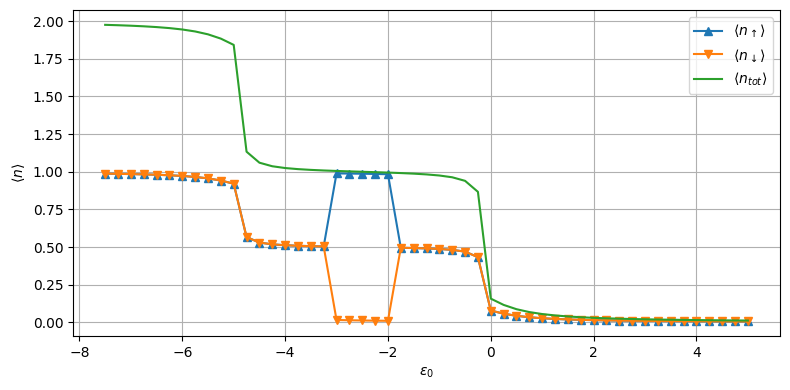

```python
%run SIAM_MFT.ipynb
n_up_list, n_dn_list, n_tot,e0array = create_spins_list(nup_i=0.6, ndn_i=0.4)
show_plot()
# Try n_up not equal to n_dn
```

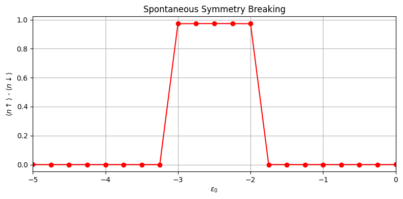

```python
plot_spin_diff()
```

## What do we calculate?

### Spectral Function

$$A_{d\sigma}(\omega) = \frac{-1}{\pi} Im G_{d\sigma}^R(\omega)$$

Where, $$G_{d\sigma}^R(\omega^+) = {\langle \langle c_{d\sigma} : c_{d\sigma}^\dagger \rangle \rangle}_\omega$$

$$\langle \hat{n}_\uparrow(\downarrow) \rangle = \frac{1}{2} - \frac{1}{\pi} tan^{-1} \left(\frac{\bar{\epsilon_0 + U\langle \hat{n}_\uparrow(\downarrow)\rangle}}{\Delta}\right)$$

## Spectral Function Plot using NRG Ljubljana Code

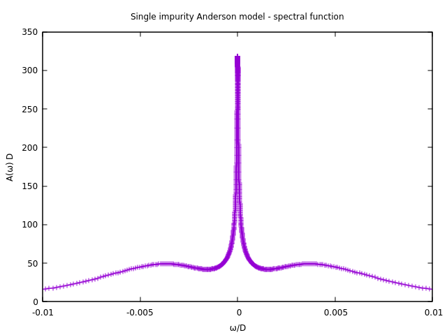

```python
show_("SIAM_spectral_fn.png")
```

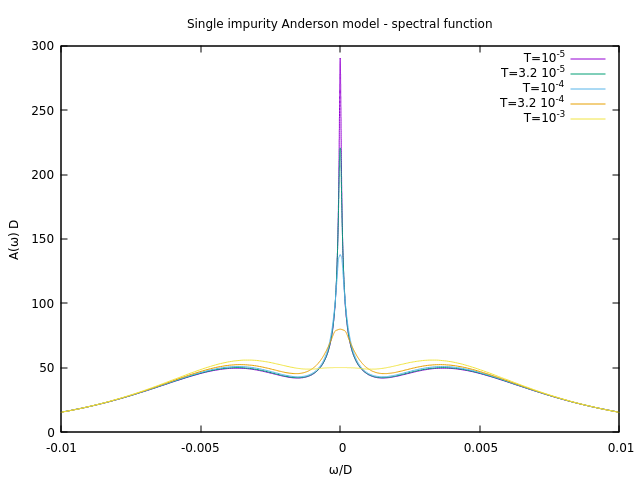

```python
show_("Spectral_fn_SIAM_T.png")
```